# Sama Amr Habib

## Transactions Data Bank ⛔||⛔ Fraud Detection

### Project Overview:

The goal of this project is to help a bank identify fraudulent transactions in their dataset and predict future fraudulent transactions using machine learning models. Fraud detection is crucial because it minimizes financial losses and maintains the trust of customers.

### Business Problem:

Fraudulent transactions can result in significant financial damage to the bank and its customers. The mission was to analyze a dataset of over 1 million transactions to identify patterns of fraud and then build a predictive model to flag potentially fraudulent transactions before they occur.

isFraud ||➡️ 0 = no fraud \ 1= fraud

### The mission:

1. make the analysis in this data set
2. create model using ML for predated any future transaction fraud or not.

# Import Libraries

```python
import pandas as pd
import numpy as np
import matplotlib.pyplot as plt
import seaborn as sns
%matplotlib inline
import plotly.graph_objects as go
import plotly.express as px
plt.style.use("ggplot")


from sklearn.model_selection import train_test_split
from sklearn.metrics import accuracy_score,r2_score, classification_report
from sklearn.linear_model import LogisticRegression
from sklearn.tree import DecisionTreeClassifier
from sklearn.neighbors import  KNeighborsClassifier
from sklearn.ensemble import RandomForestClassifier
from sklearn.neural_network import  MLPClassifier
from sklearn.svm import SVC
from sklearn.preprocessing import LabelEncoder
from imblearn.over_sampling import SMOTE
from sklearn.metrics import classification_report, confusion_matrix, roc_auc_score


from sklearn.model_selection import train_test_split
from sklearn.ensemble import RandomForestClassifier, AdaBoostClassifier
from sklearn.linear_model import LogisticRegression
from sklearn.tree import DecisionTreeClassifier
from sklearn.svm import SVC
from sklearn.metrics import classification_report, confusion_matrix, roc_auc_score
import numpy as np
import pandas as pd
import seaborn as sns
import matplotlib.pyplot as plt
```

# Data Exploration

```python
df=pd.read_csv("Fraud.csv")
```

```python
df.head()
```

|  | Date | nameOrig | amount | oldbalanceOrg | newbalanceOrig | City | type | Card Type | Exp Type | Gender | isFraud |
| --- | --- | --- | --- | --- | --- | --- | --- | --- | --- | --- | --- |
| 0 | 26-May-13 | C2011200430 | 242.0 | 302.0 | 60.0 | Ahmedabad, India | TRANSFER | Gold | Food | F | 1 |
| 1 | 26-Jul-12 | C931301500 | 7081.0 | 46066.0 | 38985.0 | Delhi, India | TRANSFER | Gold | Entertainment | M | 1 |
| 2 | 12-Apr-12 | C963642457 | 16355.0 | 30355.0 | 14000.0 | Kolkata, India | TRANSFER | Silver | Fuel | F | 1 |
| 3 | 28-Jan-12 | C1439438217 | 20820.0 | 39663.0 | 18843.0 | Lucknow, India | TRANSFER | Gold | Food | F | 1 |
| 4 | 16-Apr-14 | C892940485 | 6071.0 | 35586.0 | 29515.0 | Bengaluru, India | TRANSFER | Gold | Fuel | M | 1 |

```python
df.tail()
```

|  | Date | nameOrig | amount | oldbalanceOrg | newbalanceOrig | City | type | Card Type | Exp Type | Gender | isFraud |
| --- | --- | --- | --- | --- | --- | --- | --- | --- | --- | --- | --- |
| 1048569 | 20-Jan-14 | C1273896430 | 105150.78 | 38300000.0 | 38194849.22 | Kanpur, India | CASH_IN | Platinum | Fuel | F | 0 |
| 1048570 | 06-Mar-14 | C1450387949 | 376022.62 | 38600000.0 | 38223977.38 | Kanpur, India | CASH_IN | Gold | Grocery | F | 0 |
| 1048571 | 13-Mar-13 | C1040382471 | 77083.57 | 38400000.0 | 38322916.43 | Jaipur, India | CASH_IN | Gold | Fuel | F | 0 |
| 1048572 | 02-Apr-14 | C1576842193 | 121569.82 | 38400000.0 | 38278430.18 | Surat, India | CASH_IN | Platinum | Grocery | F | 0 |
| 1048573 | 02-Apr-13 | C1841909664 | 6808.99 | 38900000.0 | 38893191.01 | Lucknow, India | CASH_IN | Signature | Bills | M | 0 |

# Data Preprocessing

```python
df.info()
```

```
<class 'pandas.core.frame.DataFrame'>
RangeIndex: 1048574 entries, 0 to 1048573
Data columns (total 11 columns):
 #   Column          Non-Null Count    Dtype
---  ------          --------------    -----
 0   Date            1048574 non-null  object
 1   nameOrig        1048574 non-null  object
 2   amount          1048574 non-null  float64
 3   oldbalanceOrg   1048574 non-null  float64
 4   newbalanceOrig  1048574 non-null  float64
 5   City            1048574 non-null  object
 6   type            1048574 non-null  object
 7   Card Type       1048574 non-null  object
 8   Exp Type        1048574 non-null  object
 9   Gender          1048574 non-null  object
 10  isFraud         1048574 non-null  int64
dtypes: float64(3), int64(1), object(7)
memory usage: 88.0+ MB
```

```python
df.describe()
```

|  | amount | oldbalanceOrg | newbalanceOrig | isFraud |
| --- | --- | --- | --- | --- |
| count | 1.048574e+06 | 1.048574e+06 | 1.048574e+06 | 1.048574e+06 |
| mean | 3.802767e+04 | 8.801983e+05 | 8.421706e+05 | 1.676420e-01 |
| std | 1.105168e+05 | 2.969968e+06 | 2.936373e+06 | 3.735482e-01 |
| min | 0.000000e+00 | 0.000000e+00 | 0.000000e+00 | 0.000000e+00 |
| 25% | 6.470000e+02 | 4.343812e+03 | 9.180000e+02 | 0.000000e+00 |
| 50% | 8.263000e+03 | 3.653918e+04 | 2.055200e+04 | 0.000000e+00 |
| 75% | 2.365000e+04 | 1.366425e+05 | 9.030729e+04 | 0.000000e+00 |
| max | 1.000000e+07 | 3.890000e+07 | 3.889319e+07 | 1.000000e+00 |

```python
df.shape
```

```
(1048574, 11)
```

```python
df.dtypes
```

```
Date               object
nameOrig           object
amount            float64
oldbalanceOrg     float64
newbalanceOrig    float64
City               object
type               object
Card Type          object
Exp Type           object
Gender             object
isFraud             int64
dtype: object
```

```python
df.duplicated().sum()
```

```
0
```

```python
df.isnull().sum()
```

```
Date              0
nameOrig          0
amount            0
oldbalanceOrg     0
newbalanceOrig    0
City              0
type              0
Card Type         0
Exp Type          0
Gender            0
isFraud           0
dtype: int64
```

#### Change data type to Date

```python
df["Date"]= pd.to_datetime(df["Date"])
```

```python
df.dtypes
```

```
Date              datetime64[ns]
nameOrig                  object
amount                   float64
oldbalanceOrg            float64
newbalanceOrig           float64
City                      object
type                      object
Card Type                 object
Exp Type                  object
Gender                    object
isFraud                    int64
dtype: object
```

### Business Explanation:

We have historical data of transactions, which includes details such as transaction date, origin account, transaction amount, city, type of transaction, card type, expense type, and whether the transaction was flagged as fraud or not. The goal is to understand what characteristics are common in fraudulent transactions so that we can prevent future fraud more effectively.

### Technical Process:

We loaded the dataset containing 1,048,574 transactions with features such as the transaction amount, origin balance, and whether the transaction was fraudulent. No missing values or duplicates were found, ensuring the dataset was ready for analysis. The data was preprocessed to convert the Date field into a proper date format and further categorized into numerical and categorical columns.

# EDA

#### Fraud Percentage

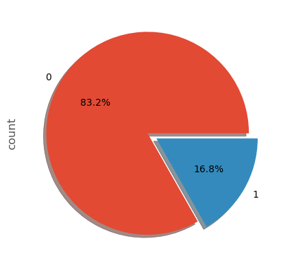

```python
df['isFraud'].value_counts().plot.pie(explode=[0,0.1],autopct='%1.1f%%',shadow=True)
```

```python
#Describe the column Amount
df["amount"].describe().round()
```

```
count     1048574.0
mean        38028.0
std        110517.0
min             0.0
25%           647.0
50%          8263.0
75%         23650.0
max      10000000.0
Name: amount, dtype: float64
```

```python
print ("The First Date :",df["Date"].min())
print ("The Last Date :",df["Date"].max())
```

```
The First Date : 2011-10-09 00:00:00
The Last Date : 2015-05-26 00:00:00
```

#### Show the trend Date with the Amount

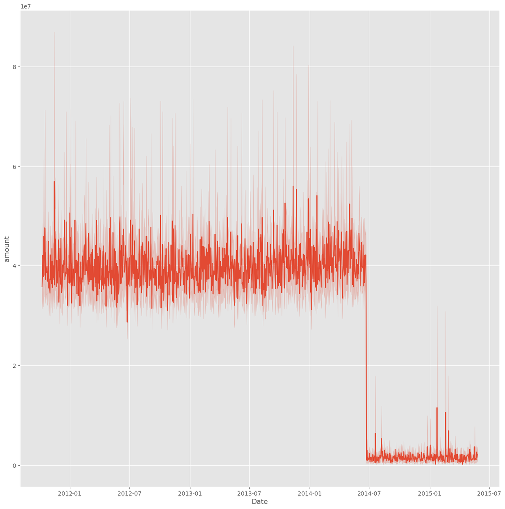

```python
plt.figure(figsize=(15,15))
sns.lineplot(df, x="Date",y="amount",estimator='sum')
```

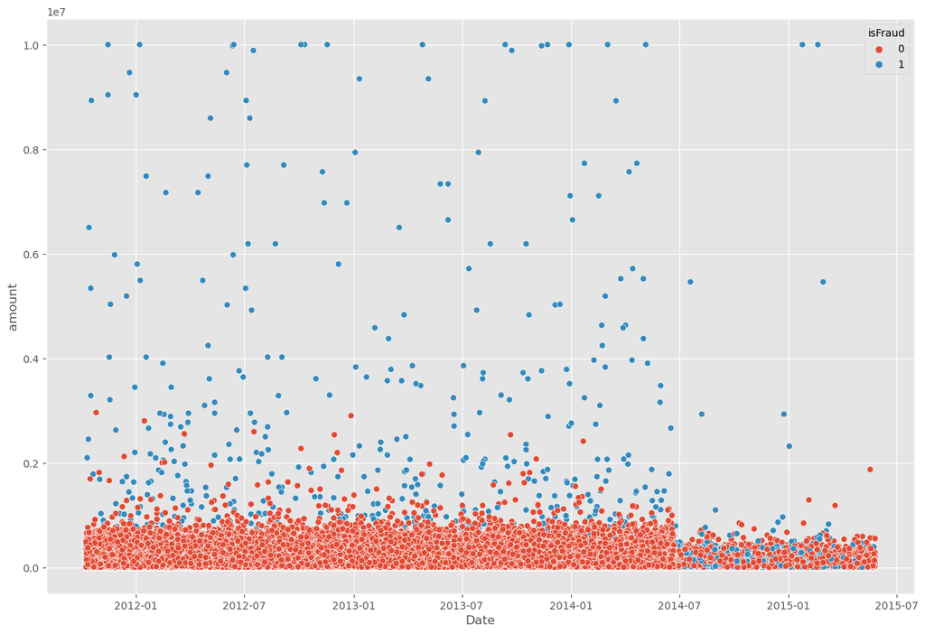

```python
plt.figure(figsize=(15,10))
sns.scatterplot(df, x="Date",y="amount",hue="isFraud")
```

##### The type transactions with the amount

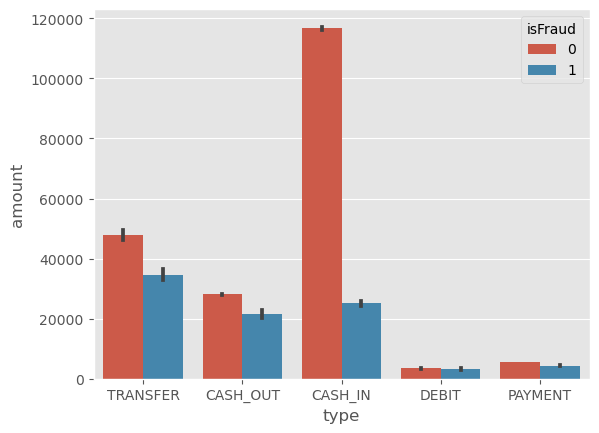

```python
sns.barplot(df,x="type",y="amount",hue="isFraud")
plt.show()
```

#### The Card Type with the amount

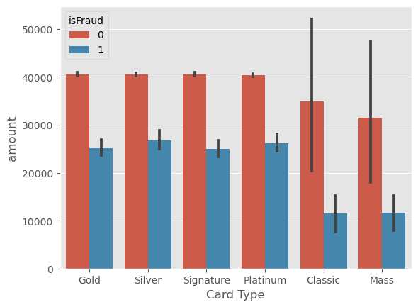

```python
sns.barplot(df,x="Card Type",y="amount",hue="isFraud")
plt.show()
```

#### Gender with the amount

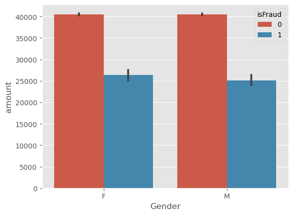

```python
sns.barplot(df,x="Gender",y="amount",hue="isFraud")
plt.show()
```

#### The Expencese Type with the amount

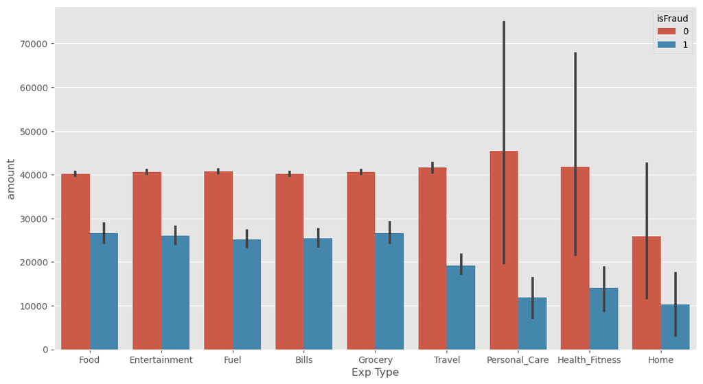

```python
plt.figure(figsize=(13,7))
sns.barplot(df,x="Exp Type",y="amount",hue="isFraud")
plt.show()
```

### Business Explanation:

This helps us spot patterns that can improve fraud detection models, such as identifying suspicious amounts or types of transactions.

### Technical Process:

We calculated descriptive statistics like average transaction amounts, distribution of fraud cases (about 16.7% of the dataset was fraudulent), and the relationship between different features (like gender, transaction type, card type, etc.) and fraud using visualizations such as bar charts and scatter plots.

## Insights

### Technical Insight:

# Modeling (Classification)

## Feature Engineering:

#### Create new three columns Day, Months, Years for ML

```python
df['day'] = df['Date'].dt.day
df['year'] = df['Date'].dt.year
df['month'] = df['Date'].dt.month
```

```python
df.head()
```

|  | Date | nameOrig | amount | oldbalanceOrg | newbalanceOrig | City | type | Card Type | Exp Type | Gender | isFraud | day | year | month |
| --- | --- | --- | --- | --- | --- | --- | --- | --- | --- | --- | --- | --- | --- | --- |
| 0 | 2013-05-26 | C2011200430 | 242.0 | 302.0 | 60.0 | Ahmedabad, India | TRANSFER | Gold | Food | F | 1 | 26 | 2013 | 5 |
| 1 | 2012-07-26 | C931301500 | 7081.0 | 46066.0 | 38985.0 | Delhi, India | TRANSFER | Gold | Entertainment | M | 1 | 26 | 2012 | 7 |
| 2 | 2012-04-12 | C963642457 | 16355.0 | 30355.0 | 14000.0 | Kolkata, India | TRANSFER | Silver | Fuel | F | 1 | 12 | 2012 | 4 |
| 3 | 2012-01-28 | C1439438217 | 20820.0 | 39663.0 | 18843.0 | Lucknow, India | TRANSFER | Gold | Food | F | 1 | 28 | 2012 | 1 |
| 4 | 2014-04-16 | C892940485 | 6071.0 | 35586.0 | 29515.0 | Bengaluru, India | TRANSFER | Gold | Fuel | M | 1 | 16 | 2014 | 4 |

#### Drop Date column

```python
df.drop(columns="Date",inplace=True)
df.head()
```

|  | nameOrig | amount | oldbalanceOrg | newbalanceOrig | City | type | Card Type | Exp Type | Gender | isFraud | day | year | month |
| --- | --- | --- | --- | --- | --- | --- | --- | --- | --- | --- | --- | --- | --- |
| 0 | C2011200430 | 242.0 | 302.0 | 60.0 | Ahmedabad, India | TRANSFER | Gold | Food | F | 1 | 26 | 2013 | 5 |
| 1 | C931301500 | 7081.0 | 46066.0 | 38985.0 | Delhi, India | TRANSFER | Gold | Entertainment | M | 1 | 26 | 2012 | 7 |
| 2 | C963642457 | 16355.0 | 30355.0 | 14000.0 | Kolkata, India | TRANSFER | Silver | Fuel | F | 1 | 12 | 2012 | 4 |
| 3 | C1439438217 | 20820.0 | 39663.0 | 18843.0 | Lucknow, India | TRANSFER | Gold | Food | F | 1 | 28 | 2012 | 1 |
| 4 | C892940485 | 6071.0 | 35586.0 | 29515.0 | Bengaluru, India | TRANSFER | Gold | Fuel | M | 1 | 16 | 2014 | 4 |

```python
df.info()
```

```
<class 'pandas.core.frame.DataFrame'>
RangeIndex: 1048574 entries, 0 to 1048573
Data columns (total 13 columns):
 #   Column          Non-Null Count    Dtype
---  ------          --------------    -----
 0   nameOrig        1048574 non-null  object
 1   amount          1048574 non-null  float64
 2   oldbalanceOrg   1048574 non-null  float64
 3   newbalanceOrig  1048574 non-null  float64
 4   City            1048574 non-null  object
 5   type            1048574 non-null  object
 6   Card Type       1048574 non-null  object
 7   Exp Type        1048574 non-null  object
 8   Gender          1048574 non-null  object
 9   isFraud         1048574 non-null  int64
 10  day             1048574 non-null  int32
 11  year            1048574 non-null  int32
 12  month           1048574 non-null  int32
dtypes: float64(3), int32(3), int64(1), object(6)
memory usage: 92.0+ MB
```

#### Separate the columns numerical and category

```python
cat = []
num = []
for i in df.columns:
    if df[i].dtypes == 'O':
        cat.append(i)
    else:
        num.append(i)

data_n=df[num]   # new dataframe just type numeric
data_c=df[cat]  # new dataframe just type object
```

```python
data_n.head()
```

|  | amount | oldbalanceOrg | newbalanceOrig | isFraud | day | year | month |
| --- | --- | --- | --- | --- | --- | --- | --- |
| 0 | 242.0 | 302.0 | 60.0 | 1 | 26 | 2013 | 5 |
| 1 | 7081.0 | 46066.0 | 38985.0 | 1 | 26 | 2012 | 7 |
| 2 | 16355.0 | 30355.0 | 14000.0 | 1 | 12 | 2012 | 4 |
| 3 | 20820.0 | 39663.0 | 18843.0 | 1 | 28 | 2012 | 1 |
| 4 | 6071.0 | 35586.0 | 29515.0 | 1 | 16 | 2014 | 4 |

```python
data_c.head()
```

|  | nameOrig | City | type | Card Type | Exp Type | Gender |
| --- | --- | --- | --- | --- | --- | --- |
| 0 | C2011200430 | Ahmedabad, India | TRANSFER | Gold | Food | F |
| 1 | C931301500 | Delhi, India | TRANSFER | Gold | Entertainment | M |
| 2 | C963642457 | Kolkata, India | TRANSFER | Silver | Fuel | F |
| 3 | C1439438217 | Lucknow, India | TRANSFER | Gold | Food | F |
| 4 | C892940485 | Bengaluru, India | TRANSFER | Gold | Fuel | M |

```python
data_n.info()
```

```
<class 'pandas.core.frame.DataFrame'>
RangeIndex: 1048574 entries, 0 to 1048573
Data columns (total 7 columns):
 #   Column          Non-Null Count    Dtype
---  ------          --------------    -----
 0   amount          1048574 non-null  float64
 1   oldbalanceOrg   1048574 non-null  float64
 2   newbalanceOrig  1048574 non-null  float64
 3   isFraud         1048574 non-null  int64
 4   day             1048574 non-null  int32
 5   year            1048574 non-null  int32
 6   month           1048574 non-null  int32
dtypes: float64(3), int32(3), int64(1)
memory usage: 44.0 MB
```

```python
data_c.info()
```

```
<class 'pandas.core.frame.DataFrame'>
RangeIndex: 1048574 entries, 0 to 1048573
Data columns (total 6 columns):
 #   Column     Non-Null Count    Dtype
---  ------     --------------    -----
 0   nameOrig   1048574 non-null  object
 1   City       1048574 non-null  object
 2   type       1048574 non-null  object
 3   Card Type  1048574 non-null  object
 4   Exp Type   1048574 non-null  object
 5   Gender     1048574 non-null  object
dtypes: object(6)
memory usage: 48.0+ MB
```

## Encoding (LabelEncoder)

```python
# change the columns type object to numeric
label_encoders = {}
categorical_columns = data_c.columns

for column in categorical_columns:
    label_encoders[column] = LabelEncoder()
    data_c[column] = label_encoders[column].fit_transform(data_c[column])
```

[output not shown]

#### Merge 2 data set

```python
frames = [data_c, data_n]

data1 = pd.concat(frames,axis=1)
data1.head()
```

|  | nameOrig | City | type | Card Type | Exp Type | Gender | amount | oldbalanceOrg | newbalanceOrig | isFraud | day | year | month |
| --- | --- | --- | --- | --- | --- | --- | --- | --- | --- | --- | --- | --- | --- |
| 0 | 547668 | 8 | 4 | 1 | 2 | 0 | 242.0 | 302.0 | 60.0 | 1 | 26 | 2013 | 5 |
| 1 | 1010877 | 126 | 4 | 1 | 1 | 1 | 7081.0 | 46066.0 | 38985.0 | 1 | 26 | 2012 | 7 |
| 2 | 1028382 | 267 | 4 | 5 | 3 | 0 | 16355.0 | 30355.0 | 14000.0 | 1 | 12 | 2012 | 4 |
| 3 | 238124 | 300 | 4 | 1 | 2 | 0 | 20820.0 | 39663.0 | 18843.0 | 1 | 28 | 2012 | 1 |
| 4 | 990085 | 71 | 4 | 1 | 3 | 1 | 6071.0 | 35586.0 | 29515.0 | 1 | 16 | 2014 | 4 |

```python
df2=data1
```

```python
df2.head()
```

|  | nameOrig | City | type | Card Type | Exp Type | Gender | amount | oldbalanceOrg | newbalanceOrig | isFraud | day | year | month |
| --- | --- | --- | --- | --- | --- | --- | --- | --- | --- | --- | --- | --- | --- |
| 0 | 547668 | 8 | 4 | 1 | 2 | 0 | 242.0 | 302.0 | 60.0 | 1 | 26 | 2013 | 5 |
| 1 | 1010877 | 126 | 4 | 1 | 1 | 1 | 7081.0 | 46066.0 | 38985.0 | 1 | 26 | 2012 | 7 |
| 2 | 1028382 | 267 | 4 | 5 | 3 | 0 | 16355.0 | 30355.0 | 14000.0 | 1 | 12 | 2012 | 4 |
| 3 | 238124 | 300 | 4 | 1 | 2 | 0 | 20820.0 | 39663.0 | 18843.0 | 1 | 28 | 2012 | 1 |
| 4 | 990085 | 71 | 4 | 1 | 3 | 1 | 6071.0 | 35586.0 | 29515.0 | 1 | 16 | 2014 | 4 |

```python
X = df2.drop(columns="isFraud")
y = df2["isFraud"]
```

#### Split the data train and test

```python
X_train, X_test, y_train, y_test = train_test_split(X, y, test_size=0.25, random_state=42)

print("X Train : ", X_train.shape)
print("X Test  : ", X_test.shape)
print("Y Train : ", y_train.shape)
print("Y Test  : ", y_test.shape)
```

```
X Train :  (786430, 12)
X Test  :  (262144, 12)
Y Train :  (786430,)
Y Test  :  (262144,)
```

#### Models

```python
LR = LogisticRegression()
DTR = DecisionTreeClassifier()
RFR = RandomForestClassifier()
KNR = KNeighborsClassifier()
```

#### Make for loop for classification

```python
li = [LR,DTR,RFR,KNR]
d = {}
for i in li:
    i.fit(X_train,y_train)
    ypred = i.predict(X_test)
    print(i,":",accuracy_score(y_test,ypred)*100)
    print(i,":",classification_report(y_test,ypred))
    print("********************************************")
```

```
LogisticRegression() : 83.282470703125
LogisticRegression() :               precision    recall  f1-score   support

           0       0.83      1.00      0.91    218287
           1       1.00      0.00      0.00     43857

    accuracy                           0.83    262144
   macro avg       0.92      0.50      0.46    262144
weighted avg       0.86      0.83      0.76    262144

DecisionTreeClassifier() : 81.07376098632812
DecisionTreeClassifier() :               precision    recall  f1-score   support

           0       0.89      0.88      0.89    218287
           1       0.44      0.45      0.44     43857

    accuracy                           0.81    262144
   macro avg       0.66      0.67      0.67    262144
weighted avg       0.81      0.81      0.81    262144

RandomForestClassifier() : 86.64894104003906
RandomForestClassifier() :               precision    recall  f1-score   support

           0       0.88      0.97      0.92    218287
           1       0.71      0.34      0.46     43857

    accuracy                           0.87    262144
   macro avg       0.80      0.66      0.69    262144
weighted avg       0.85      0.87      0.85    262144

KNeighborsClassifier() : 80.70755004882812
KNeighborsClassifier() :               precision    recall  f1-score   support

           0       0.85      0.93      0.89    218287
           1       0.36      0.20      0.26     43857

    accuracy                           0.81    262144
   macro avg       0.61      0.57      0.57    262144
weighted avg       0.77      0.81      0.78    262144
```

Note:

Generally, recall is often prioritized because the primary goal is to catch as many fraudulent transactions as possible, even at the risk of flagging some legitimate transactions as fraud (false positives).

##### focusing on recall is likely the best approach to ensure it captures as many fraudulent transactions as possible.

#### Handle Class Imbalance

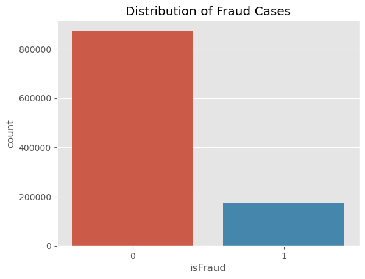

```python
# Count plot for isFraud
sns.countplot(x='isFraud', data=df2)
plt.title('Distribution of Fraud Cases')
plt.show()
```

#### Oversampling the Minority Class

SMOTE (Synthetic Minority Over-sampling Technique) to create synthetic samples.

```python
# Instantiate SMOTE
smote = SMOTE(random_state=42)

# Apply SMOTE
X_train_resampled, y_train_resampled = smote.fit_resample(X_train, y_train)
```

```python
# Train the Random Forest model
rf_model = RandomForestClassifier(random_state=42)
rf_model.fit(X_train_resampled, y_train_resampled)
```

```
RandomForestClassifier(random_state=42)
```

```python
# Make predictions on the test set
y_pred = rf_model.predict(X_test)
```

```python
# Evaluate the model
from sklearn.metrics import classification_report, confusion_matrix, roc_auc_score

# Classification report
print("Classification Report:")
print(classification_report(y_test, y_pred))

# Confusion matrix
print("Confusion Matrix:")
print(confusion_matrix(y_test, y_pred))

# AUC-ROC score (if you have the probability predictions)
y_pred_proba = rf_model.predict_proba(X_test)[:, 1]
print(f'AUC-ROC: {roc_auc_score(y_test, y_pred_proba)}')
```

```
Classification Report:
              precision    recall  f1-score   support

           0       0.91      0.86      0.88    218287
           1       0.45      0.56      0.50     43857

    accuracy                           0.81    262144
   macro avg       0.68      0.71      0.69    262144
weighted avg       0.83      0.81      0.82    262144

Confusion Matrix:
[[187767  30520]
 [ 19080  24777]]
AUC-ROC: 0.8520837808246062
```

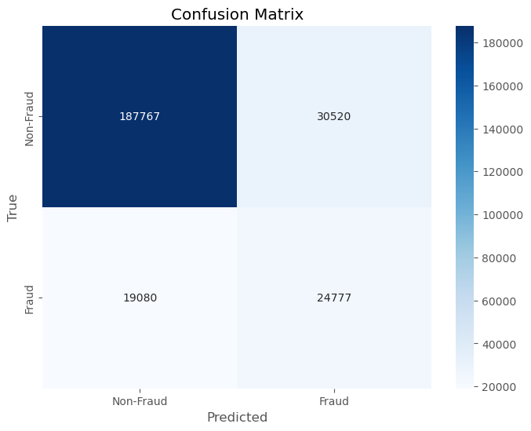

```python
# Visualize the results
# Confusion Matrix Visualization
cm = confusion_matrix(y_test, y_pred)
plt.figure(figsize=(8, 6))
sns.heatmap(cm, annot=True, fmt='d', cmap='Blues', xticklabels=['Non-Fraud', 'Fraud'], yticklabels=['Non-Fraud', 'Fraud'])
plt.xlabel('Predicted')
plt.ylabel('True')
plt.title('Confusion Matrix')
plt.show()
```

[output not shown]

[figure not shown]

[output not shown]

[figure not shown]

[output not shown]

[figure not shown]

```python
# Define the models
models = {
    'Logistic Regression': LogisticRegression(max_iter=2000, random_state=42),
    'Random Forest': RandomForestClassifier(random_state=42),
    'Decision Tree': DecisionTreeClassifier(random_state=42),
    'Support Vector Classifier': SVC(probability=True, random_state=42),
    'AdaBoost': AdaBoostClassifier(random_state=42)
}

# Loop through the models
for model_name, model in models.items():
    model.fit(X_train_resampled, y_train_resampled)  # Fit the model on resampled data
    y_pred = model.predict(X_test)  # Make predictions on the original test set
    y_pred_proba = model.predict_proba(X_test)[:, 1]  # Get probability predictions for AUC-ROC

    # Evaluate the model
    print(f"Model: {model_name}")
    print("Classification Report:")
    print(classification_report(y_test, y_pred))

    print("Confusion Matrix:")
    print(confusion_matrix(y_test, y_pred))

    print(f'AUC-ROC: {roc_auc_score(y_test, y_pred_proba)}')
    print("********************************************")

    # Optional: Confusion Matrix Visualization
    cm = confusion_matrix(y_test, y_pred)
    plt.figure(figsize=(8, 6))
    sns.heatmap(cm, annot=True, fmt='d', cmap='Blues', xticklabels=['Non-Fraud', 'Fraud'], yticklabels=['Non-Fraud', 'Fraud'])
    plt.xlabel('Predicted')
    plt.ylabel('True')
    plt.title(f'Confusion Matrix for {model_name}')
    plt.show()
```

### Business Explanation:

We built a machine learning model that learns from past fraudulent transactions and applies that knowledge to predict whether new transactions are likely to be fraudulent. This helps the bank stop fraudulent transactions before they cause damage.

### Technical Process:

We engineered new features such as the day, month, and year from the transaction date to give the model more temporal data to learn from. We then categorized the data into numerical and categorical types, which allowed us to build a classification model. This model takes input data and outputs a prediction: 0 for no fraud, 1 for fraud.

### Business Explanation:

The model will predict whether a transaction is fraudulent based on patterns in the historical data, like unusually high amounts or transactions in specific cities with certain card types. If a transaction matches a fraud pattern, it will flag it, allowing the bank to investigate further before processing.

### Technical Process:

1. Preventing Loss: With accurate fraud detection, the bank can reduce financial losses due to fraud. Each fraudulent transaction caught early prevents potential damage to customers and the bank's reputation.
2. Customer Trust: By safeguarding customer transactions, we enhance trust, ensuring that the bank's customers feel secure when making transactions.

# Summary:

```
This project helps the bank proactively detect and prevent fraudulent transactions. Using historical data and machine learning, we identified key fraud patterns and built a model to predict future frauds. The system flags suspicious transactions based on characteristics like high transaction amounts, specific types of expenses, and unusual transaction patterns, allowing the bank to investigate these transactions before they cause any damage.
```